# 重賞レース予測レポート【レース終了】

作成日時: 2026/02/10 20:46:47

☞ [マニュアル(pdf)](https://ryutoro-galois.github.io/keiba-predictor/manual/manual.pdf)

☞ 過去6年の同一レース結果: [2025年](https://ryutoro-galois.github.io/keiba-predictor/report/PredResult_2025y_raceDate_20250209_20250209.html), [2024年](https://ryutoro-galois.github.io/keiba-predictor/report/PredResult_2024y_raceDate_20240204_20240204.html), [2023年](https://ryutoro-galois.github.io/keiba-predictor/report/PredResult_2023y_raceDate_20230205_20230205.html), [2022年](https://ryutoro-galois.github.io/keiba-predictor/report/PredResult_2022y_raceDate_20220206_20220206.html), [2021年](https://ryutoro-galois.github.io/keiba-predictor/report/PredResult_2021y_raceDate_20210207_20210207.html), [2020年](https://ryutoro-galois.github.io/keiba-predictor/report/PredResult_2020y_raceDate_20200209_20200209.html)

☞ 過去4週間の別レース結果: [1週前(2/1)](https://ryutoro-galois.github.io/keiba-predictor/report/PredResult_2026y_raceDate_20260201_20260201.html), [2週前(1/24-25)](https://ryutoro-galois.github.io/keiba-predictor/report/PredResult_2026y_raceDate_20260124_20260125.html), [3週前(1/18)](https://ryutoro-galois.github.io/keiba-predictor/report/PredResult_2026y_raceDate_20260118_20260118.html), [4週前(1/11-12)](https://ryutoro-galois.github.io/keiba-predictor/report/PredResult_2026y_raceDate_20260111_20260112.html)

☞ netkeiba: [東京新聞杯(GⅢ)](https://race.netkeiba.com/race/result.html?race_id=202605010411&rf=race_submenu), [きさらぎ賞(GⅢ)](https://race.netkeiba.com/race/result.html?race_id=202608020411&rf=race_submenu)

☞ レース結果(csv): [2/7-8](https://ryutoro-galois.github.io/keiba-predictor/csv/race_result_20260207_20260208.csv)

## 【レース結果(1)】人気と着順の関係

### 【東京新聞杯(2026/02/08(日))】

【東京新聞杯(GⅢ)】  
2026/02/08(日), 05_東京, 芝左1600m

[interactive chart not shown]

### 【きさらぎ賞(2026/02/08(日))】

【きさらぎ賞(GⅢ)】  
2026/02/08(日), 08_京都, 芝右外1800m

[interactive chart not shown]

## 【レース結果(2)】コーナー通過順位

### 【東京新聞杯(2026/02/08(日))】

【東京新聞杯(GⅢ)】  
2026/02/08(日), 05_東京, 芝左1600m

[interactive chart not shown]

### 【きさらぎ賞(2026/02/08(日))】

【きさらぎ賞(GⅢ)】  
2026/02/08(日), 08_京都, 芝右外1800m

[interactive chart not shown]

## 0. 推し馬予測 (AI予測)

### 【東京新聞杯(GⅢ) 2026/02/08(日)】

- 本命(◎): 1-3着内確率(勝負強さ)が1位の馬
- 対抗(◯): 1-3着内確率が2-N位(20%程度以上)の中で予測タイムが最も速い馬
- 3番手(▲): 1-3着内確率が2-N位(20%程度以上)のでダークホース確率が最も高い馬
- 穴: ダークホース確率が上位1-M位(40%程度以上)の中で1-3着内確率が最も高い馬

| 推し馬 | 枠番 | 馬番 | 人気 | オッズ | 馬名 | 騎手 | 調教師 | 予測タイム(sec) | 1_順位 | 1-3着内確率(%) | 2_順位 | ﾀﾞｰｸﾎｰｽ確率(%) | 3_順位 |
| --- | --- | --- | --- | --- | --- | --- | --- | --- | --- | --- | --- | --- | --- |
| 本命(◎) | 4 | 7 | 2 | 5.6 | トロヴァトーレ | Ｃ．ルメール | 鹿戸雄一 | 96.4 | 3 | 52.9 | 1 | 0.6 | 14 |
| 対抗(◯) | 6 | 12 | 3 | 5.8 | ウォーターリヒト | 高杉吏麒 | 石橋守 | 98.4 | 10 | 21.5 | 2 | 0.4 | 15 |
| 3番手(▲) | 2 | 4 | 7 | 10.9 | マジックサンズ | 武豊 | 須貝尚介 | 95.9 | 2 | 19.0 | 3 | 1.3 | 9 |
| 穴 | 2 | 3 | 13 | 31.2 | シリウスコルト | 三浦皇成 | 田中勝春 | 96.5 | 4 | 8.4 | 8 | 43.9 | 1 |

### 【きさらぎ賞(GⅢ) 2026/02/08(日)】

- 本命(◎): 1-3着内確率(勝負強さ)が1位の馬
- 対抗(◯): 1-3着内確率が2-N位(20%程度以上)の中で予測タイムが最も速い馬
- 3番手(▲): 1-3着内確率が2-N位(20%程度以上)のでダークホース確率が最も高い馬
- 穴: ダークホース確率が上位1-M位(40%程度以上)の中で1-3着内確率が最も高い馬

| 推し馬 | 枠番 | 馬番 | 人気 | オッズ | 馬名 | 騎手 | 調教師 | 予測タイム(sec) | 1_順位 | 1-3着内確率(%) | 2_順位 | ﾀﾞｰｸﾎｰｽ確率(%) | 3_順位 |
| --- | --- | --- | --- | --- | --- | --- | --- | --- | --- | --- | --- | --- | --- |
| 本命(◎) | 4 | 4 | 3 | 4.2 | ゴーイントゥスカイ | 荻野極 | 上原佑紀 | 115.7 | 6 | 33.3 | 1 | 0.5 | 7 |
| 対抗(◯) | 2 | 2 | 2 | 3.7 | エムズビギン | 川田将雅 | 友道康夫 | 115.1 | 2 | 27.3 | 2 | 0.4 | 9 |
| 3番手(▲) | 8 | 9 | 6 | 10.9 | ローベルクランツ | 松山弘平 | 小林真也 | 115.5 | 4 | 7.2 | 6 | 29.3 | 3 |
| 穴 | 3 | 3 | 9 | 59.5 | サトノアイボリー | 団野大成 | 杉山晴紀 | 115.5 | 3 | 7.1 | 7 | 41.4 | 1 |

## 1. 予測チャート (タイム/勝負強さ)

### 【東京新聞杯(GⅢ)】

2026/02/08(日), 05_東京, 芝左1600m

[interactive chart not shown]

### 【きさらぎ賞(GⅢ)】

2026/02/08(日), 08_京都, 芝右外1800m

[interactive chart not shown]

## 2. オッズモニタリング (毎時)

### 【東京新聞杯】

[interactive chart not shown]

### 【きさらぎ賞】

[interactive chart not shown]

## 3. 出馬表

### 【東京新聞杯 2026/02/08(日) 】

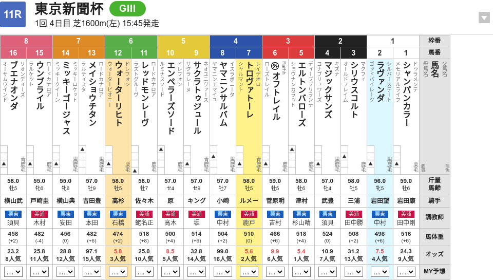

### 【きさらぎ賞 2026/02/08(日) 】

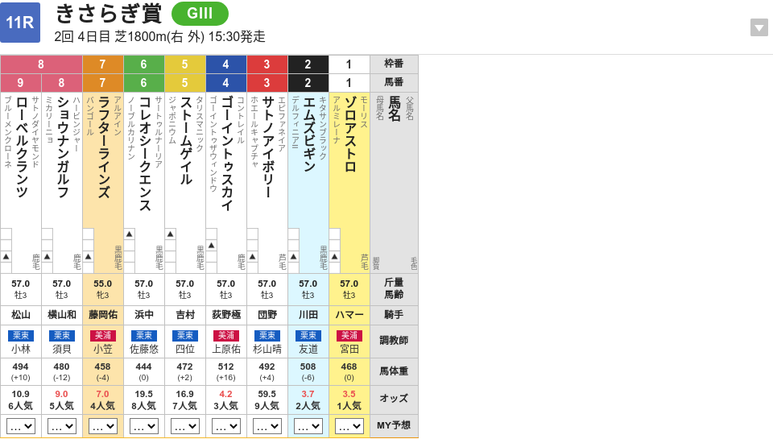

## 4. 単勝予測結果

### 【東京新聞杯(GⅢ) 2026/02/08(日)】

| 枠番 | 馬番 | 人気 | オッズ | 馬名 | 騎手 | 調教師 | 予測タイム(sec) | 1_順位 | 1-3着内確率(%) | 2_順位 | ﾀﾞｰｸﾎｰｽ確率(%) | 3_順位 |
| --- | --- | --- | --- | --- | --- | --- | --- | --- | --- | --- | --- | --- |
| 1 | 1 | 9 | 24.3 | シャンパンカラー | 岩田康誠 | 田中剛 | 100.5 | 16 | 7.7 | 10 | 15.4 | 5 |
| 1 | 2 | 4 | 7.5 | ラヴァンダ | 岩田望来 | 中村直也 | 99.5 | 15 | 16.5 | 5 | 0.8 | 13 |
| 2 | 3 | 13 | 31.2 | シリウスコルト | 三浦皇成 | 田中勝春 | 96.5 | 4 | 8.4 | 8 | 43.9 | 1 |
| 2 | 4 | 7 | 10.9 | マジックサンズ | 武豊 | 須貝尚介 | 95.9 | 2 | 19.0 | 3 | 1.3 | 9 |
| 3 | 5 | 1 | 5.4 | エルトンバローズ | 津村明秀 | 杉山晴紀 | 91.9 | 1 | 12.8 | 6 | 0.4 | 16 |
| 3 | 6 | 6 | 9.9 | オフトレイル | 菅原明良 | 吉村圭司 | 97.2 | 5 | 18.8 | 4 | 1.2 | 11 |
| 4 | 7 | 2 | 5.6 | トロヴァトーレ | Ｃ．ルメール | 鹿戸雄一 | 96.4 | 3 | 52.9 | 1 | 0.6 | 14 |
| 4 | 8 | 16 | 99.0 | ヤマニンサルバム | 小崎綾也 | 中村直也 | 98.4 | 12 | 2.9 | 16 | 27.4 | 4 |
| 5 | 9 | 14 | 32.8 | サクラトゥジュール | Ｒ．キング | 堀宣行 | 97.4 | 7 | 6.7 | 11 | 15.3 | 6 |
| 5 | 10 | 5 | 8.5 | エンペラーズソード | 原優介 | 高木登 | 98.4 | 11 | 8.6 | 7 | 1.0 | 12 |

[output cut: 6 more lines]

### 【きさらぎ賞(GⅢ) 2026/02/08(日)】

| 枠番 | 馬番 | 人気 | オッズ | 馬名 | 騎手 | 調教師 | 予測タイム(sec) | 1_順位 | 1-3着内確率(%) | 2_順位 | ﾀﾞｰｸﾎｰｽ確率(%) | 3_順位 |
| --- | --- | --- | --- | --- | --- | --- | --- | --- | --- | --- | --- | --- |
| 1 | 1 | 1 | 3.5 | ゾロアストロ | Ｔ．ハマーハンセン | 宮田敬介 | 106.9 | 1 | 16.0 | 3 | 0.5 | 8 |
| 2 | 2 | 2 | 3.7 | エムズビギン | 川田将雅 | 友道康夫 | 115.1 | 2 | 27.3 | 2 | 0.4 | 9 |
| 3 | 3 | 9 | 59.5 | サトノアイボリー | 団野大成 | 杉山晴紀 | 115.5 | 3 | 7.1 | 7 | 41.4 | 1 |
| 4 | 4 | 3 | 4.2 | ゴーイントゥスカイ | 荻野極 | 上原佑紀 | 115.7 | 6 | 33.3 | 1 | 0.5 | 7 |
| 5 | 5 | 7 | 16.9 | ストームゲイル | 吉村誠之助 | 四位洋文 | 116.2 | 8 | 3.5 | 9 | 11.3 | 4 |
| 6 | 6 | 8 | 19.5 | コレオシークエンス | 浜中俊 | 佐藤悠太 | 115.7 | 5 | 5.9 | 8 | 40.8 | 2 |
| 7 | 7 | 4 | 7.0 | ラフターラインズ | 藤岡佑介 | 小笠倫弘 | 116.4 | 9 | 7.5 | 5 | 0.8 | 6 |
| 8 | 8 | 5 | 9.0 | ショウナンガルフ | 横山和生 | 須貝尚介 | 115.7 | 7 | 11.1 | 4 | 1.8 | 5 |
| 8 | 9 | 6 | 10.9 | ローベルクランツ | 松山弘平 | 小林真也 | 115.5 | 4 | 7.2 | 6 | 29.3 | 3 |

## 5. 人気と着順の乖離率推移

### 【東京新聞杯_1990y_2019y】

[interactive chart not shown]

### 【きさらぎ賞_1990y_2019y】

[interactive chart not shown]

### 【東京新聞杯_1990y_2019y】

| No | 開催年 | 不整合率(%) | 頭数 | 人気別着順(1-3位) | 人気別着順(全体) |
| --- | --- | --- | --- | --- | --- |
| 29 | 2019 | 27.0 | 15頭 | 1-6-4 | 1\|6\|4\|10\|2\|15\|9\|5\|3\|13\|12\|7\|14\|8\|11 |
| 28 | 2018 | 57.6 | 16頭 | 3-5-2 | 3\|5\|2\|9\|11\|8\|13\|4\|1\|12\|7\|6\|14\|10\|15\|16 |
| 27 | 2017 | 46.5 | 10頭 | 3-5-1 | 3\|5\|1\|4\|10\|2\|8\|6\|7\|9 |
| 26 | 2016 | 48.7 | 13頭 | 5-6-11 | 5\|6\|11\|2\|8\|4\|12\|10\|7\|3\|9\|14\|13 |
| 25 | 2015 | 40.4 | 16頭 | 3-9-1 | 3\|9\|1\|4\|8\|2\|7\|15\|11\|6\|5\|10\|14\|13\|12\|16 |
| 24 | 2014 | 48.4 | 14頭 | 8-3-5 | 8\|3\|5\|1\|4\|6\|10\|11\|13\|2\|9\|14\|7\|12 |
| 23 | 2013 | 52.8 | 16頭 | 2-5-4 | 2\|5\|4\|8\|9\|10\|13\|7\|3\|1\|6\|16\|14\|11\|12\|15 |
| 22 | 2012 | 40.1 | 16頭 | 8-4-7 | 8\|4\|7\|9\|1\|6\|2\|5\|13\|11\|12\|15\|3\|16\|14\|10 |
| 21 | 2011 | 46.2 | 16頭 | 5-7-2 | 5\|7\|2\|12\|13\|4\|1\|11\|6\|8\|3\|10\|15\|16\|9\|14 |
| 20 | 2010 | 26.5 | 16頭 | 2-1-6 | 2\|1\|6\|5\|13\|3\|4\|9\|8\|15\|11\|14\|7\|10\|16\|12 |

[output cut: 19 more lines]

### 【きさらぎ賞_1990y_2019y】

| No | 開催年 | 不整合率(%) | 頭数 | 人気別着順(1-3位) | 人気別着順(全体) |
| --- | --- | --- | --- | --- | --- |
| 30 | 2019 | 50.8 | 8頭 | 3-6-7 | 3\|6\|7\|1\|5\|8\|2\|4 |
| 29 | 2018 | 60.5 | 10頭 | 4-2-5 | 4\|2\|5\|7\|3\|9\|10\|6\|1\|8 |
| 28 | 2017 | 16.1 | 7頭 | 6-1-2 | 6\|1\|2\|3\|7\|8\|4 |
| 27 | 2016 | 20.6 | 9頭 | 1-4-2 | 1\|4\|2\|5\|8\|7\|3\|9\|6 |
| 26 | 2015 | 9.0 | 8頭 | 1-2-3 | 1\|2\|3\|6\|7\|5\|4\|8 |
| 25 | 2014 | 30.0 | 9頭 | 2-1-6 | 2\|1\|6\|4\|8\|3\|7\|5\|9 |
| 24 | 2013 | 87.2 | 8頭 | 6-5-3 | 6\|5\|3\|4\|7\|2\|8\|1 |
| 23 | 2012 | 15.7 | 13頭 | 1-4-2 | 1\|4\|2\|3\|6\|7\|8\|10\|5\|9\|11\|12\|13 |
| 22 | 2011 | 47.2 | 12頭 | 3-8-2 | 3\|8\|2\|1\|5\|4\|6\|10\|9\|7\|12\|11 |
| 21 | 2010 | 32.6 | 11頭 | 5-1-6 | 5\|1\|6\|3\|2\|4\|7\|10\|8\|9\|11 |

[output cut: 20 more lines]

## 6. 1-3番人気馬の着順分類予測

### 【東京新聞杯】

| 分類 | 凡例 | 発生確率(%) | 当該レース | 当該レースランク | 直近1年間 |
| --- | --- | --- | --- | --- | --- |
| 1: 1番人気のみ (1_pop1) | 1 \| * \| * | 17.3 | 0.67 | 1.02 | 0.35 |
| 4: 1,2番人気のみ (4_pop12) | 1 \| 2 \| * | 16.1 | 0.80 | 0.67 | 0.00 |
| 8: 1,2,3番人気すべて着外 (8_darkhorse) | * \| * \| * | 15.9 | 0.93 | 1.61 | 0.00 |
| 5: 1,3番人気のみ (5_pop13) | 1 \| 3 \| * | 13.5 | 1.18 | 1.36 | 0.00 |
| 3: 3番人気のみ (3_pop3) | 3 \| * \| * | 10.9 | 1.91 | 0.64 | 0.22 |
| 6: 2,3番人気のみ (6_pop23) | 2 \| 3 \| * | 9.7 | 3.34 | 2.31 | 0.00 |
| 2: 2番人気のみ (2_pop2) | 2 \| * \| * | 9.2 | 0.81 | 0.93 | 0.00 |
| 7: 1,2,3番人気すべて着内 (7_pop123) | 1 \| 2 \| 3 | 7.4 | 1.30 | 0.87 | 0.00 |

### 【きさらぎ賞】

| 分類 | 凡例 | 発生確率(%) | 当該レース | 当該レースランク | 直近1年間 |
| --- | --- | --- | --- | --- | --- |
| 1: 1番人気のみ (1_pop1) | 1 \| * \| * | 16.2 | 1.95 | 0.96 | 0.32 |
| 3: 3番人気のみ (3_pop3) | 3 \| * \| * | 15.4 | 0.55 | 0.91 | 0.31 |
| 4: 1,2番人気のみ (4_pop12) | 1 \| 2 \| * | 15.3 | 0.55 | 0.64 | 0.00 |
| 8: 1,2,3番人気すべて着外 (8_darkhorse) | * \| * \| * | 15.1 | 5.39 | 1.53 | 0.00 |
| 5: 1,3番人気のみ (5_pop13) | 1 \| 3 \| * | 13.0 | 1.57 | 1.31 | 0.00 |
| 6: 2,3番人気のみ (6_pop23) | 2 \| 3 \| * | 9.2 | 1.64 | 2.19 | 0.00 |
| 2: 2番人気のみ (2_pop2) | 2 \| * \| * | 8.7 | 1.05 | 0.88 | 0.00 |
| 7: 1,2,3番人気すべて着内 (7_pop123) | 1 \| 2 \| 3 | 7.1 | 0.64 | 0.84 | 0.00 |

## 7. 3連複予測結果

### 【東京新聞杯(GⅢ) 2026/02/08(日)】

| 分類 | 馬番 | 枠番 | 人気 | 平均予測タイム(sec) | 1-3着内確率(%) | ﾀﾞｰｸﾎｰｽ確率(%) | 馬名 | 騎手 | 調教師 |
| --- | --- | --- | --- | --- | --- | --- | --- | --- | --- |
| 6: 2,3番人気のみ (6_pop23) | 7-12-4 | 4-6-2 | 2-3-7 | 96.90 | 2.16 | 0.00 | トロヴァトーレ \| ウォーターリヒト \| マジックサンズ | Ｃ．ルメール \| 高杉吏麒 \| 武豊 | 鹿戸雄一 \| 石橋守 \| 須貝尚介 |
| 6: 2,3番人気のみ (6_pop23) | 7-12-6 | 4-6-3 | 2-3-6 | 97.33 | 2.13 | 0.00 | トロヴァトーレ \| ウォーターリヒト \| オフトレイル | Ｃ．ルメール \| 高杉吏麒 \| 菅原明良 | 鹿戸雄一 \| 石橋守 \| 吉村圭司 |
| 2: 2番人気のみ (2_pop2) | 7-6-4 | 4-3-2 | 2-6-7 | 96.50 | 1.89 | 0.00 | トロヴァトーレ \| オフトレイル \| マジックサンズ | Ｃ．ルメール \| 菅原明良 \| 武豊 | 鹿戸雄一 \| 吉村圭司 \| 須貝尚介 |
| 6: 2,3番人気のみ (6_pop23) | 7-12-2 | 4-6-1 | 2-3-4 | 98.10 | 1.88 | 0.00 | トロヴァトーレ \| ウォーターリヒト \| ラヴァンダ | Ｃ．ルメール \| 高杉吏麒 \| 岩田望来 | 鹿戸雄一 \| 石橋守 \| 中村直也 |
| 2: 2番人気のみ (2_pop2) | 7-2-4 | 4-1-2 | 2-4-7 | 97.27 | 1.66 | 0.00 | トロヴァトーレ \| ラヴァンダ \| マジックサンズ | Ｃ．ルメール \| 岩田望来 \| 武豊 | 鹿戸雄一 \| 中村直也 \| 須貝尚介 |
| 2: 2番人気のみ (2_pop2) | 7-2-6 | 4-1-3 | 2-4-6 | 97.70 | 1.64 | 0.00 | トロヴァトーレ \| ラヴァンダ \| オフトレイル | Ｃ．ルメール \| 岩田望来 \| 菅原明良 | 鹿戸雄一 \| 中村直也 \| 吉村圭司 |
| 7: 1,2,3番人気すべて着内 (7_pop123) | 5-7-12 | 3-4-6 | 1-2-3 | 95.57 | 1.46 | 0.00 | エルトンバローズ \| トロヴァトーレ \| ウォーターリヒト | 津村明秀 \| Ｃ．ルメール \| 高杉吏麒 | 杉山晴紀 \| 鹿戸雄一 \| 石橋守 |
| 4: 1,2番人気のみ (4_pop12) | 5-7-4 | 3-4-2 | 1-2-7 | 94.73 | 1.29 | 0.00 | エルトンバローズ \| トロヴァトーレ \| マジックサンズ | 津村明秀 \| Ｃ．ルメール \| 武豊 | 杉山晴紀 \| 鹿戸雄一 \| 須貝尚介 |
| 4: 1,2番人気のみ (4_pop12) | 5-7-6 | 3-4-3 | 1-2-6 | 95.17 | 1.28 | 0.00 | エルトンバローズ \| トロヴァトーレ \| オフトレイル | 津村明秀 \| Ｃ．ルメール \| 菅原明良 | 杉山晴紀 \| 鹿戸雄一 \| 吉村圭司 |
| 4: 1,2番人気のみ (4_pop12) | 5-7-2 | 3-4-1 | 1-2-4 | 95.93 | 1.12 | 0.00 | エルトンバローズ \| トロヴァトーレ \| ラヴァンダ | 津村明秀 \| Ｃ．ルメール \| 岩田望来 | 杉山晴紀 \| 鹿戸雄一 \| 中村直也 |

[output cut: 550 more lines]

### 【きさらぎ賞(GⅢ) 2026/02/08(日)】

| 分類 | 馬番 | 枠番 | 人気 | 平均予測タイム(sec) | 1-3着内確率(%) | ﾀﾞｰｸﾎｰｽ確率(%) | 馬名 | 騎手 | 調教師 |
| --- | --- | --- | --- | --- | --- | --- | --- | --- | --- |
| 7: 1,2,3番人気すべて着内 (7_pop123) | 1-2-4 | 1-2-4 | 1-2-3 | 112.57 | 1.45 | 0.00 | ゾロアストロ \| エムズビギン \| ゴーイントゥスカイ | Ｔ．ハマーハンセン \| 川田将雅 \| 荻野極 | 宮田敬介 \| 友道康夫 \| 上原佑紀 |
| 6: 2,3番人気のみ (6_pop23) | 2-4-8 | 2-4-8 | 2-3-5 | 115.50 | 1.01 | 0.00 | エムズビギン \| ゴーイントゥスカイ \| ショウナンガルフ | 川田将雅 \| 荻野極 \| 横山和生 | 友道康夫 \| 上原佑紀 \| 須貝尚介 |
| 6: 2,3番人気のみ (6_pop23) | 2-4-7 | 2-4-7 | 2-3-4 | 115.73 | 0.68 | 0.00 | エムズビギン \| ゴーイントゥスカイ \| ラフターラインズ | 川田将雅 \| 荻野極 \| 藤岡佑介 | 友道康夫 \| 上原佑紀 \| 小笠倫弘 |
| 6: 2,3番人気のみ (6_pop23) | 2-4-9 | 2-4-8 | 2-3-6 | 115.43 | 0.66 | 0.00 | エムズビギン \| ゴーイントゥスカイ \| ローベルクランツ | 川田将雅 \| 荻野極 \| 松山弘平 | 友道康夫 \| 上原佑紀 \| 小林真也 |
| 6: 2,3番人気のみ (6_pop23) | 2-4-3 | 2-4-3 | 2-3-9 | 115.43 | 0.64 | 0.00 | エムズビギン \| ゴーイントゥスカイ \| サトノアイボリー | 川田将雅 \| 荻野極 \| 団野大成 | 友道康夫 \| 上原佑紀 \| 杉山晴紀 |
| 5: 1,3番人気のみ (5_pop13) | 1-4-8 | 1-4-8 | 1-3-5 | 112.77 | 0.59 | 0.00 | ゾロアストロ \| ゴーイントゥスカイ \| ショウナンガルフ | Ｔ．ハマーハンセン \| 荻野極 \| 横山和生 | 宮田敬介 \| 上原佑紀 \| 須貝尚介 |
| 6: 2,3番人気のみ (6_pop23) | 2-4-6 | 2-4-6 | 2-3-8 | 115.50 | 0.54 | 0.00 | エムズビギン \| ゴーイントゥスカイ \| コレオシークエンス | 川田将雅 \| 荻野極 \| 浜中俊 | 友道康夫 \| 上原佑紀 \| 佐藤悠太 |
| 4: 1,2番人気のみ (4_pop12) | 1-2-8 | 1-2-8 | 1-2-5 | 112.57 | 0.48 | 0.00 | ゾロアストロ \| エムズビギン \| ショウナンガルフ | Ｔ．ハマーハンセン \| 川田将雅 \| 横山和生 | 宮田敬介 \| 友道康夫 \| 須貝尚介 |
| 5: 1,3番人気のみ (5_pop13) | 1-4-7 | 1-4-7 | 1-3-4 | 113.00 | 0.40 | 0.00 | ゾロアストロ \| ゴーイントゥスカイ \| ラフターラインズ | Ｔ．ハマーハンセン \| 荻野極 \| 藤岡佑介 | 宮田敬介 \| 上原佑紀 \| 小笠倫弘 |
| 5: 1,3番人気のみ (5_pop13) | 1-4-9 | 1-4-8 | 1-3-6 | 112.70 | 0.39 | 0.00 | ゾロアストロ \| ゴーイントゥスカイ \| ローベルクランツ | Ｔ．ハマーハンセン \| 荻野極 \| 松山弘平 | 宮田敬介 \| 上原佑紀 \| 小林真也 |

[output cut: 74 more lines]

## 8. 直近の全レース情報

[output not shown]